# Question 10

Raju Bhujel (22)

10. Use the four variables of “USArrests” data file into R Studio and do as follows with R script to knit PDF output.
1. Fit a k-means clustering model in the data with k = 2, plot it in the single graph and interpret it carefully

```
# Load the USArrests dataset
data("USArrests")

# Scale the data
scaled_data <- scale(USArrests)

# Perform k-means clustering with k=2
set.seed(123)  # for reproducibility
km2 <- kmeans(scaled_data, centers = 2, nstart = 25)

# Plot the clusters
fviz_cluster(km2, data = scaled_data,
             palette = c("#2E9FDF", "#FC4E07"),
             geom = "point",
             ellipse.type = "convex",
             ggtheme = theme_minimal(),
             main = "K-means Clustering with K=2")
```

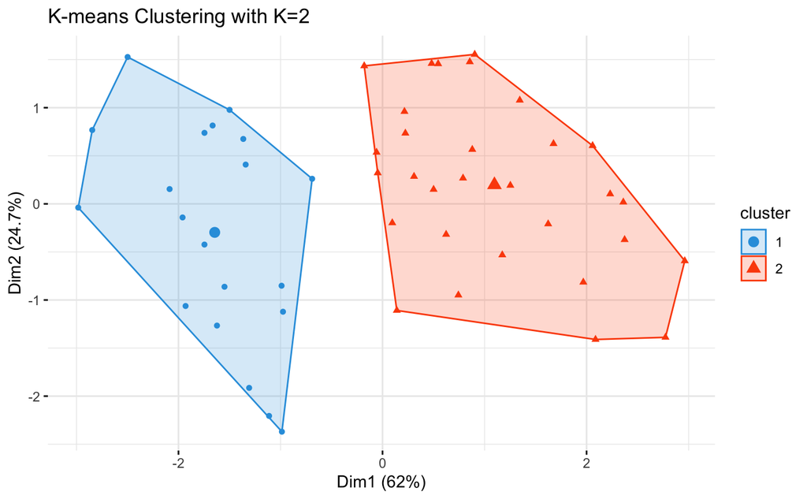

2. Add cluster centers for the plot of clusters formed with k = 2 and interpret it carefully

```
# Plot clusters with centers
fviz_cluster(km2, data = scaled_data,
             palette = c("#2E9FDF", "#FC4E07"),
             geom = c("point", "text"),
             ellipse.type = "convex",
             ggtheme = theme_minimal(),
             main = "K-means Clustering with K=2 (Including Centers)")
```

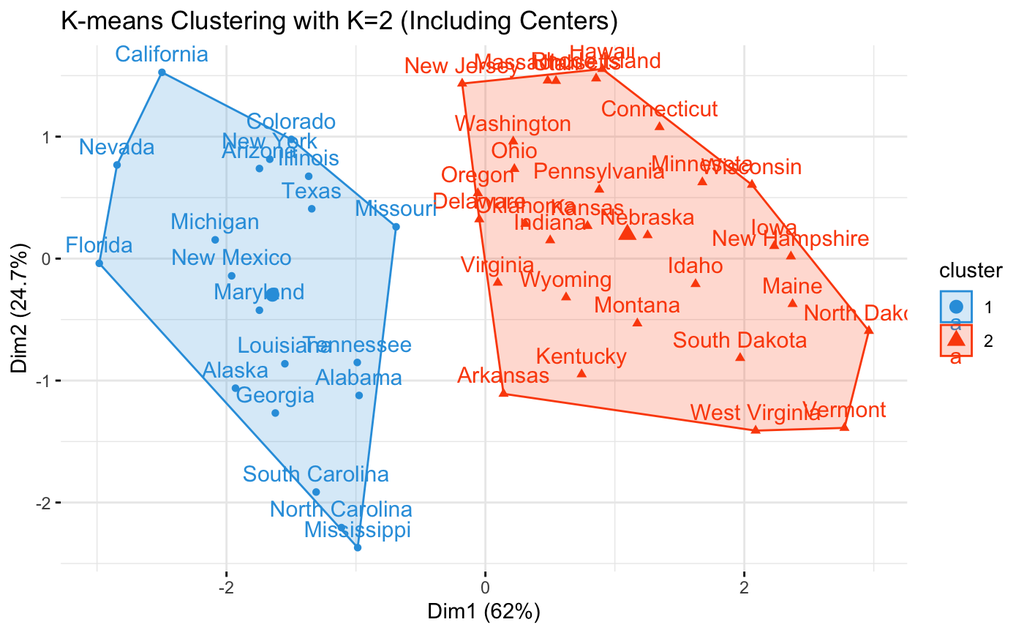

```
# Print cluster centers
print("Cluster Centers:")
```

```
[1] "Cluster Centers:"
```

```
print(km2$centers)
```

```
     Murder    Assault   UrbanPop       Rape
1  1.004934  1.0138274  0.1975853  0.8469650
2 -0.669956 -0.6758849 -0.1317235 -0.5646433
```

**Interpretation of Cluster Centers for k=2:** The cluster centers represent the average values of the four variables (Murder, Assault, UrbanPop, and Rape) for each cluster. These centers help us understand the characteristics of each cluster: - The cluster centers show the average crime rates and urban population percentage for each group - The distance between centers indicates how distinct the clusters are - States closer to a center are more typical of that cluster’s characteristics

3. Fit a k-means clustering model in the data with k = 3, plot it in the single graph and interpret it carefully

```
# Perform k-means clustering with k=3
set.seed(123)
km3 <- kmeans(scaled_data, centers = 3, nstart = 25)

# Plot the clusters
fviz_cluster(km3, data = scaled_data,
             palette = c("#2E9FDF", "#FC4E07", "#00AFBB"),
             geom = "point",
             ellipse.type = "convex",
             ggtheme = theme_minimal(),
             main = "K-means Clustering with K=3")
```

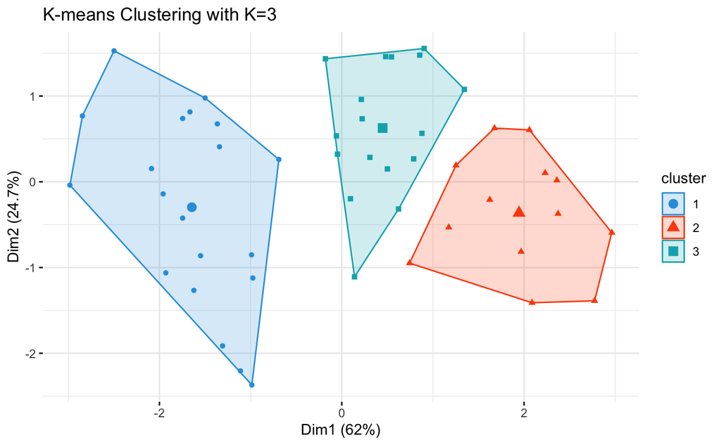

4. Add cluster centers for the plot of clusters formed with k = 3 and interpret it carefully

```
# Plot clusters with centers
fviz_cluster(km3, data = scaled_data,
             palette = c("#2E9FDF", "#FC4E07", "#00AFBB"),
             geom = c("point", "text"),
             ellipse.type = "convex",
             ggtheme = theme_minimal(),
             main = "K-means Clustering with K=3 (Including Centers)")
```

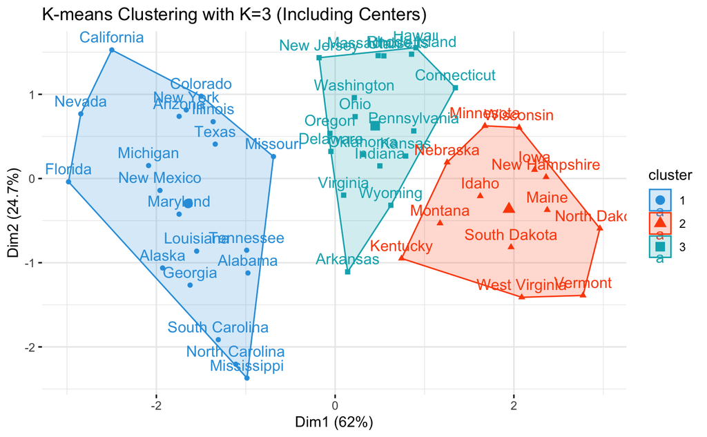

```
# Print cluster centers
print("Cluster Centers:")
```

```
[1] "Cluster Centers:"
```

```
print(km3$centers)
```

```
      Murder    Assault   UrbanPop       Rape
1  1.0049340  1.0138274  0.1975853  0.8469650
2 -0.9615407 -1.1066010 -0.9301069 -0.9667633
3 -0.4469795 -0.3465138  0.4788049 -0.2571398
```

**Interpretation of Cluster Centers for k=3:** The three cluster centers provide more detailed insights into the crime patterns: - Each center represents the average characteristics of its cluster - The relative positions of the centers show how the clusters differ in terms of crime rates and urban population - The distances between centers indicate the distinctness of each cluster - This three-cluster solution provides a more granular view of crime patterns across US states compared to the two-cluster solution